# Lab 05 - Wrangling spatial data

Ye Dam Yi

3/2/2021

```r
devtools::install_github("rstudio-education/dsbox")
install.packages("tiff", type="source")
```

```r
library(tidyverse)
```

```r
library(dsbox)
library(imager)
```

#### Data declaration

```r
dn <- dennys
lq <- laquinta
```

#### Ex 1. Filter the Denny’s dataframe for Alaska (AK) and save the result as dn_ak. How many Denny’s locations are there in Alaska?

```r
dn_ak <- dn %>%
  filter(state == "AK") # filter for Denny's locations in AK
nrow(dn_ak)             # count the number of observations
```

```
## [1] 3
```

There are three Denny’s locations in Alaska.

#### Ex 2. Filter the La Quinta dataframe for Alaska (AK) and save the result as lq_ak. How many La Quinta locations are there in Alaska?

```r
lq_ak <- lq %>%
  filter(state == "AK")
nrow(lq_ak)
```

```
## [1] 2
```

There are two La Quinta’s locations in Alaska.

### Next we’ll calculate the distance between all Denny’s and all La Quinta locations in Alaska.

#### Ex 3. How many pairings are there between all Denny’s and all La Quinta locations in Alaska, i.e., how many distances do we need to calculate between the locations of these establishments in Alaska?

We need to calculate 2 X 3 = 6 distances between the locations of all Denny’s and La Quinta in Alaska.

In order to calculate these six distances, we first need to combine the two dataframes by using join. The resulting dataframe will contain a table looking like this:

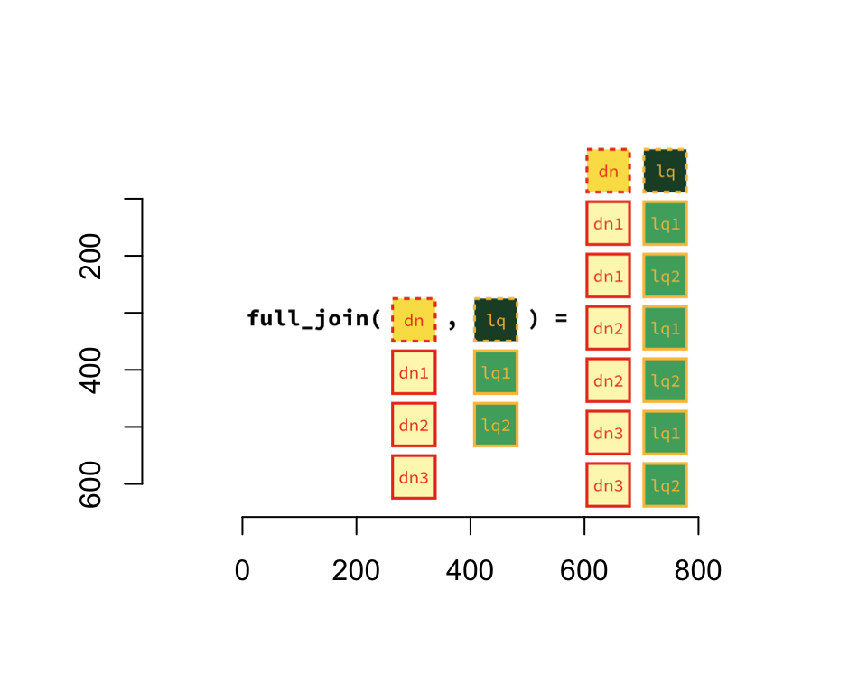

```r
im <- load.image("/Users/yedam/Documents/GitHub/DSP/LAB/lab-05-wrangling-data/dennys-laquinta-sketches.004.png")
plot(im)
```

```r
dn_lq_ak <- full_join(dn_ak, lq_ak, by = "state")
dn_lq_ak
```

```
## # A tibble: 6 x 11
##   address.x   city.x state zip.x longitude.x latitude.x address.y  city.y  zip.y
##   <chr>       <chr>  <chr> <chr>       <dbl>      <dbl> <chr>      <chr>   <chr>
## 1 2900 Denali Ancho… AK    99503       -150.       61.2 3501 Minn… "\nAnc… 99503
## 2 2900 Denali Ancho… AK    99503       -150.       61.2 4920 Dale… "\nFai… 99709
## 3 3850 Debar… Ancho… AK    99508       -150.       61.2 3501 Minn… "\nAnc… 99503
## 4 3850 Debar… Ancho… AK    99508       -150.       61.2 4920 Dale… "\nFai… 99709
## 5 1929 Airpo… Fairb… AK    99701       -148.       64.8 3501 Minn… "\nAnc… 99503
## 6 1929 Airpo… Fairb… AK    99701       -148.       64.8 4920 Dale… "\nFai… 99709
## # … with 2 more variables: longitude.y <dbl>, latitude.y <dbl>
```

#### Ex 4. How many observations are in the joined dn_lq_ak data frame? What are the names of the variables in this data frame.

Note: .x in the variable names means the variable comes from the x data frame (the first argument in the full_join call, i.e. dn_ak), and .y means the variable comes from the y data frame. These variables are renamed to include .x and .y because the two data frames have the same variables and it’s not possible to have two variables in a data frame with the exact same name.

#### Ex 5. What function from the tidyverse do we use the add a new variable to a data frame while keeping the existing variables?

```r
# there's no built in r function so we use the formula to create a function in r
haversine <- function(long1, lat1, long2, lat2, round = 3) {
  # convert to radians
  long1 = long1 * pi / 180
  lat1  = lat1  * pi / 180
  long2 = long2 * pi / 180
  lat2  = lat2  * pi / 180

  R = 6371 # Earth mean radius in km

  a = sin((lat2 - lat1)/2)^2 + cos(lat1) * cos(lat2) * sin((long2 - long1)/2)^2
  d = R * 2 * asin(sqrt(a))

  return( round(d,round) ) # distance in km
}
```

#### Ex 6. Calculate the distances between all pairs of Denny’s and La Quinta locations and save this variable as distance. Make sure to save this variable in THE dn_lq_ak data frame so that you can use it later.

```r
dn_lq_ak <- dn_lq_ak %>%
  mutate(distance = haversine(longitude.x, latitude.x, longitude.y, latitude.y, round = 3))
dn_lq_ak
```

```
## # A tibble: 6 x 12
##   address.x   city.x state zip.x longitude.x latitude.x address.y  city.y  zip.y
##   <chr>       <chr>  <chr> <chr>       <dbl>      <dbl> <chr>      <chr>   <chr>
## 1 2900 Denali Ancho… AK    99503       -150.       61.2 3501 Minn… "\nAnc… 99503
## 2 2900 Denali Ancho… AK    99503       -150.       61.2 4920 Dale… "\nFai… 99709
## 3 3850 Debar… Ancho… AK    99508       -150.       61.2 3501 Minn… "\nAnc… 99503
## 4 3850 Debar… Ancho… AK    99508       -150.       61.2 4920 Dale… "\nFai… 99709
## 5 1929 Airpo… Fairb… AK    99701       -148.       64.8 3501 Minn… "\nAnc… 99503
## 6 1929 Airpo… Fairb… AK    99701       -148.       64.8 4920 Dale… "\nFai… 99709
## # … with 3 more variables: longitude.y <dbl>, latitude.y <dbl>, distance <dbl>
```

#### Ex 7. Calculate the minimum distance between a Denny’s and La Quinta for each Denny’s location. To do so we group by Denny’s locations and calculate a new variable that stores the information for the minimum distance.

```r
dn_lq_ak_mindist <- dn_lq_ak %>%
  group_by(address.x) %>%
  summarise(closest = min(distance))  # note the function closest = min(distance) as part of summarise
dn_lq_ak_mindist
```

```
## # A tibble: 3 x 2
##   address.x        closest
## * <chr>              <dbl>
## 1 1929 Airport Way    5.20
## 2 2900 Denali         2.04
## 3 3850 Debarr Road    6.00
```

#### Ex 8. Describe the distribution of the distances between Denny’s and the nearest La Quinta locations in Alaska. Also include an appripriate visualization and relevant summary statistics.

Any of Denny’s locations in Alaksa is within six kilometers of a La Quinta’s location in the same state.

```r
(dn_lq_ak_mindist_sum <- dn_lq_ak_mindist %>%
  summarize(m = mean(closest)))
```

```
## # A tibble: 1 x 1
##       m
##   <dbl>
## 1  4.41
```

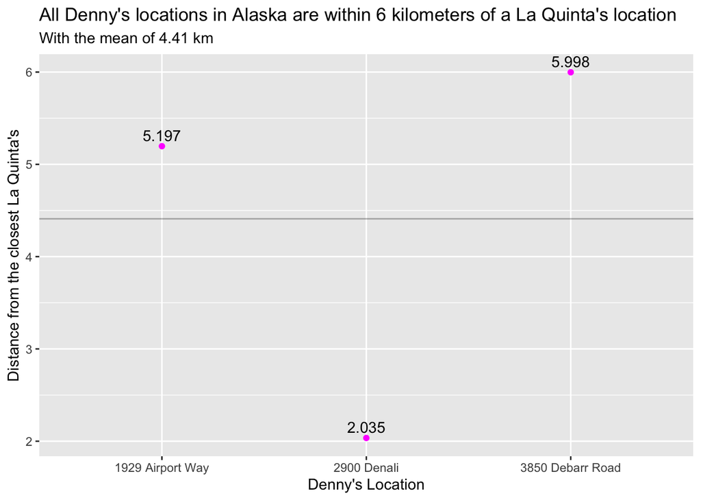

```r
dn_lq_ak_mindist %>%
  ggplot(aes(x = address.x, y = closest)) +
  geom_point(color = "magenta") +
  geom_text(mapping = aes(label =  closest), vjust = -.5) +
  geom_abline(intercept = 4.41, slope = 0, alpha = .3) +
  labs(
    title = "All Denny's locations in Alaska are within 6 kilometers of a La Quinta's location",
    x = "Denny's Location",
    y = "Distance from the closest La Quinta's",
    subtitle = "With the mean of 4.41 km"
  )
```

#### Ex 9. Repeat the same analysis for North Carolina

```r
# (i) filter Denny’s and La Quinta Data Frames for NC
dn_nc <- dn %>%
  filter(state == "NC") # filter for Denny's locations in NC
nrow(dn_nc)
```

```
## [1] 28
```

```r
lq_nc <- lq %>%
  filter(state == "NC") # filter for La Quinta's locations in NC
nrow(lq_nc)
```

```
## [1] 12
```

```r
# (ii) join these data frames to get a complete list of all possible pairings
dn_lq_nc <- full_join(dn_nc, lq_nc, by = "state")
dn_lq_nc
```

```
## # A tibble: 336 x 11
##    address.x  city.x  state zip.x longitude.x latitude.x address.y  city.y zip.y
##    <chr>      <chr>   <chr> <chr>       <dbl>      <dbl> <chr>      <chr>  <chr>
##  1 1 Regent … Ashevi… NC    28806       -82.6       35.6 165 Hwy 1… "\nBo… 28607
##  2 1 Regent … Ashevi… NC    28806       -82.6       35.6 3127 Sloa… "\nCh… 28208
##  3 1 Regent … Ashevi… NC    28806       -82.6       35.6 4900 Sout… "\nCh… 28217
##  4 1 Regent … Ashevi… NC    28806       -82.6       35.6 4414 Durh… "\nDu… 27707
##  5 1 Regent … Ashevi… NC    28806       -82.6       35.6 1910 West… "\nDu… 27713
##  6 1 Regent … Ashevi… NC    28806       -82.6       35.6 1201 Lana… "\nGr… 27407
##  7 1 Regent … Ashevi… NC    28806       -82.6       35.6 1607 Fair… "\nCo… 28613
##  8 1 Regent … Ashevi… NC    28806       -82.6       35.6 191 Cresc… "\nCa… 27518
##  9 1 Regent … Ashevi… NC    28806       -82.6       35.6 2211 Summ… "\nRa… 27612
## 10 1 Regent … Ashevi… NC    28806       -82.6       35.6 1001 Aeri… "\nMo… 27560
## # … with 326 more rows, and 2 more variables: longitude.y <dbl>,
## #   latitude.y <dbl>
```

```r
# (iii) calculate the distances between all possible pairings of Denny’s and La Quinta in NC
dn_lq_nc <- dn_lq_nc %>%
  mutate(distance = haversine(longitude.x, latitude.x, longitude.y, latitude.y, round = 3))
dn_lq_nc
```

```
## # A tibble: 336 x 12
##    address.x  city.x  state zip.x longitude.x latitude.x address.y  city.y zip.y
##    <chr>      <chr>   <chr> <chr>       <dbl>      <dbl> <chr>      <chr>  <chr>
##  1 1 Regent … Ashevi… NC    28806       -82.6       35.6 165 Hwy 1… "\nBo… 28607
##  2 1 Regent … Ashevi… NC    28806       -82.6       35.6 3127 Sloa… "\nCh… 28208
##  3 1 Regent … Ashevi… NC    28806       -82.6       35.6 4900 Sout… "\nCh… 28217
##  4 1 Regent … Ashevi… NC    28806       -82.6       35.6 4414 Durh… "\nDu… 27707
##  5 1 Regent … Ashevi… NC    28806       -82.6       35.6 1910 West… "\nDu… 27713
##  6 1 Regent … Ashevi… NC    28806       -82.6       35.6 1201 Lana… "\nGr… 27407
##  7 1 Regent … Ashevi… NC    28806       -82.6       35.6 1607 Fair… "\nCo… 28613
##  8 1 Regent … Ashevi… NC    28806       -82.6       35.6 191 Cresc… "\nCa… 27518
##  9 1 Regent … Ashevi… NC    28806       -82.6       35.6 2211 Summ… "\nRa… 27612
## 10 1 Regent … Ashevi… NC    28806       -82.6       35.6 1001 Aeri… "\nMo… 27560
## # … with 326 more rows, and 3 more variables: longitude.y <dbl>,
## #   latitude.y <dbl>, distance <dbl>
```

```r
# (iv) find the minimum distance between each Denny’s and La Quinta location
dn_lq_nc_mindist <- dn_lq_nc %>%
  group_by(address.x) %>%
  summarise(closest = min(distance))  # note the function closest = min(distance) as part of summarise
dn_lq_nc_mindist
```

```
## # A tibble: 28 x 2
##    address.x                 closest
##  * <chr>                       <dbl>
##  1 1 Regent Park Boulevard     108.
##  2 101 Wintergreen Dr          120.
##  3 103 Sedgehill Dr             26.7
##  4 1043 Jimmie Kerr Road        36.1
##  5 1201 S College Road         188.
##  6 1209 Burkemount Avenue       39.1
##  7 1493 Us Hwy 74-A Bypass      70.1
##  8 1524 Dabney Dr               59.5
##  9 1550 Four Seasons           115.
## 10 1800 Princeton-Kenly Road    55.9
## # … with 18 more rows
```

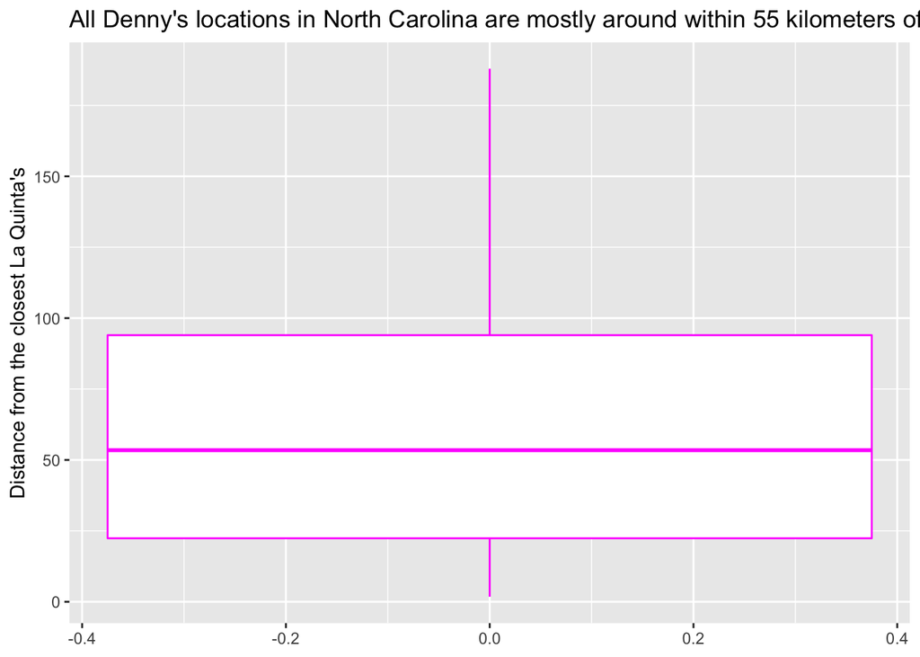

```r
# (v) visualize and describe the distribution of these shortest distances using appropriate summary statistics.
dn_lq_nc_mindist %>%
  ggplot(aes(y = closest)) +
  geom_boxplot(color = "magenta") +
  labs(
    title = "All Denny's locations in North Carolina are mostly around within 55 kilometers of a La Quinta's location",
    y = "Distance from the closest La Quinta's"
  )
```

#### Ex 10. Repeat the same analysis for Texas.

```r
# create dataset
dn_tx <- dn %>%
  filter(state == "TX")
nrow(dn_tx)
```

```
## [1] 200
```

```r
lq_tx <- lq %>%
  filter(state == "TX")
nrow(lq_tx)
```

```
## [1] 237
```

```r
# join the two datasets
dn_lq_tx <- full_join(dn_tx, lq_tx, by = "state")
dn_lq_tx
```

```
## # A tibble: 47,400 x 11
##    address.x  city.x  state zip.x longitude.x latitude.x address.y  city.y zip.y
##    <chr>      <chr>   <chr> <chr>       <dbl>      <dbl> <chr>      <chr>  <chr>
##  1 120 East … Abilene TX    79601       -99.6       32.4 3018 CatC… "\nAb… 79606
##  2 120 East … Abilene TX    79601       -99.6       32.4 3501 West… "\nAb… 79601
##  3 120 East … Abilene TX    79601       -99.6       32.4 14925 Lan… "\nAd… 75254
##  4 120 East … Abilene TX    79601       -99.6       32.4 909 East … "\nAl… 78516
##  5 120 East … Abilene TX    79601       -99.6       32.4 2400 East… "\nAl… 78332
##  6 120 East … Abilene TX    79601       -99.6       32.4 1220 Nort… "\nAl… 75013
##  7 120 East … Abilene TX    79601       -99.6       32.4 1165 Hwy … "\nAl… 76009
##  8 120 East … Abilene TX    79601       -99.6       32.4 880 South… "\nAl… 77511
##  9 120 East … Abilene TX    79601       -99.6       32.4 1708 Inte… "\nAm… 79103
## 10 120 East … Abilene TX    79601       -99.6       32.4 9305 East… "\nAm… 79118
## # … with 47,390 more rows, and 2 more variables: longitude.y <dbl>,
## #   latitude.y <dbl>
```

```r
# compute distance
dn_lq_tx <- dn_lq_tx %>%
  mutate(distance = haversine(longitude.x, latitude.x, longitude.y, latitude.y, round = 3))
dn_lq_tx
```

```
## # A tibble: 47,400 x 12
##    address.x  city.x  state zip.x longitude.x latitude.x address.y  city.y zip.y
##    <chr>      <chr>   <chr> <chr>       <dbl>      <dbl> <chr>      <chr>  <chr>
##  1 120 East … Abilene TX    79601       -99.6       32.4 3018 CatC… "\nAb… 79606
##  2 120 East … Abilene TX    79601       -99.6       32.4 3501 West… "\nAb… 79601
##  3 120 East … Abilene TX    79601       -99.6       32.4 14925 Lan… "\nAd… 75254
##  4 120 East … Abilene TX    79601       -99.6       32.4 909 East … "\nAl… 78516
##  5 120 East … Abilene TX    79601       -99.6       32.4 2400 East… "\nAl… 78332
##  6 120 East … Abilene TX    79601       -99.6       32.4 1220 Nort… "\nAl… 75013
##  7 120 East … Abilene TX    79601       -99.6       32.4 1165 Hwy … "\nAl… 76009
##  8 120 East … Abilene TX    79601       -99.6       32.4 880 South… "\nAl… 77511
##  9 120 East … Abilene TX    79601       -99.6       32.4 1708 Inte… "\nAm… 79103
## 10 120 East … Abilene TX    79601       -99.6       32.4 9305 East… "\nAm… 79118
## # … with 47,390 more rows, and 3 more variables: longitude.y <dbl>,
## #   latitude.y <dbl>, distance <dbl>
```

```r
# compute the closest
dn_lq_tx_mindist <- dn_lq_tx %>%
  group_by(address.x) %>%
  summarise(closest = min(distance))
dn_lq_tx_mindist
```

```
## # A tibble: 200 x 2
##    address.x             closest
##  * <chr>                   <dbl>
##  1 100 Cottonwood         33.6
##  2 100 E Pinehurst         1.39
##  3 100 Us Highway 79 S    33.9
##  4 101 N Fm 707           10.3
##  5 1011 Beltway Parkway   14.0
##  6 1015 Spur 350 West      1.74
##  7 1015 West Main St       1.10
##  8 10367 Highway 59       37.6
##  9 10433 N Central Expwy   0.618
## 10 105 W 42nd St           6.88
## # … with 190 more rows
```

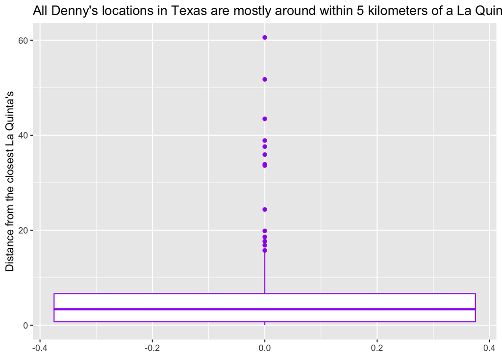

```r
# visualize the distribution of the closest distances
dn_lq_tx_mindist %>%
  ggplot(aes(y = closest)) +
  geom_boxplot(color = "purple") +
  labs(
    title = "All Denny's locations in Texas are mostly around within 5 kilometers of a La Quinta's location",
    y = "Distance from the closest La Quinta's"
  )
```

#### Ex 11. The same analysis for California

```r
# create dataset
dn_ca <- dn %>%
  filter(state == "CA")
nrow(dn_ca)
```

```
## [1] 403
```

```r
lq_ca <- lq %>%
  filter(state == "CA")
nrow(lq_ca)
```

```
## [1] 56
```

```r
# join the two datasets
dn_lq_ca <- full_join(dn_ca, lq_ca, by = "state")
dn_lq_ca
```

```
## # A tibble: 22,568 x 11
##    address.x  city.x  state zip.x longitude.x latitude.x address.y  city.y zip.y
##    <chr>      <chr>   <chr> <chr>       <dbl>      <dbl> <chr>      <chr>  <chr>
##  1 14240 Us … Adelan… CA    92301       -117.       34.5 1752 Clem… "\nAn… 92802
##  2 14240 Us … Adelan… CA    92301       -117.       34.5 8858 Spec… "\nBa… 93308
##  3 14240 Us … Adelan… CA    92301       -117.       34.5 3232 Rive… "\nBa… 93308
##  4 14240 Us … Adelan… CA    92301       -117.       34.5 920 Unive… "\nBe… 94710
##  5 14240 Us … Adelan… CA    92301       -117.       34.5 3 Centerp… "\nLa… 90623
##  6 14240 Us … Adelan… CA    92301       -117.       34.5 1771 Rese… "\nDa… 95618
##  7 14240 Us … Adelan… CA    92301       -117.       34.5 6275 Dubl… "\nDu… 94568
##  8 14240 Us … Adelan… CA    92301       -117.       34.5 316 Pittm… "\nFa… 94534
##  9 14240 Us … Adelan… CA    92301       -117.       34.5 190 N. 10… "\nFo… 93625
## 10 14240 Us … Adelan… CA    92301       -117.       34.5 46200 Lan… "\nFr… 94538
## # … with 22,558 more rows, and 2 more variables: longitude.y <dbl>,
## #   latitude.y <dbl>
```

```r
# compute distance
dn_lq_ca <- dn_lq_ca %>%
  mutate(distance = haversine(longitude.x, latitude.x, longitude.y, latitude.y, round = 3))
dn_lq_ca
```

```
## # A tibble: 22,568 x 12
##    address.x  city.x  state zip.x longitude.x latitude.x address.y  city.y zip.y
##    <chr>      <chr>   <chr> <chr>       <dbl>      <dbl> <chr>      <chr>  <chr>
##  1 14240 Us … Adelan… CA    92301       -117.       34.5 1752 Clem… "\nAn… 92802
##  2 14240 Us … Adelan… CA    92301       -117.       34.5 8858 Spec… "\nBa… 93308
##  3 14240 Us … Adelan… CA    92301       -117.       34.5 3232 Rive… "\nBa… 93308
##  4 14240 Us … Adelan… CA    92301       -117.       34.5 920 Unive… "\nBe… 94710
##  5 14240 Us … Adelan… CA    92301       -117.       34.5 3 Centerp… "\nLa… 90623
##  6 14240 Us … Adelan… CA    92301       -117.       34.5 1771 Rese… "\nDa… 95618
##  7 14240 Us … Adelan… CA    92301       -117.       34.5 6275 Dubl… "\nDu… 94568
##  8 14240 Us … Adelan… CA    92301       -117.       34.5 316 Pittm… "\nFa… 94534
##  9 14240 Us … Adelan… CA    92301       -117.       34.5 190 N. 10… "\nFo… 93625
## 10 14240 Us … Adelan… CA    92301       -117.       34.5 46200 Lan… "\nFr… 94538
## # … with 22,558 more rows, and 3 more variables: longitude.y <dbl>,
## #   latitude.y <dbl>, distance <dbl>
```

```r
# compute the closest
dn_lq_ca_mindist <- dn_lq_ca %>%
  group_by(address.x) %>%         # this is the key!
  summarise(closest = min(distance))
dn_lq_ca_mindist
```

```
## # A tibble: 403 x 2
##    address.x            closest
##  * <chr>                  <dbl>
##  1 #2 Serra Monte         6.24
##  2 10 Airport Blvd        0.093
##  3 1000 Imola Ave        14.5
##  4 1000 W Steele Lane    58.7
##  5 1001 E Capitol        13.5
##  6 1010 W Alameda Ave    24.8
##  7 1011 Riley Street     11.4
##  8 1014 N Main St       137.
##  9 1015 Blossom Hill Rd  15.4
## 10 1019 East Main St     80.3
## # … with 393 more rows
```

```r
# compute the mean
(dn_lq_ca_mindist %>%
    summarise(a = mean(closest)))
```

```
## # A tibble: 1 x 1
##       a
##   <dbl>
## 1  22.1
```

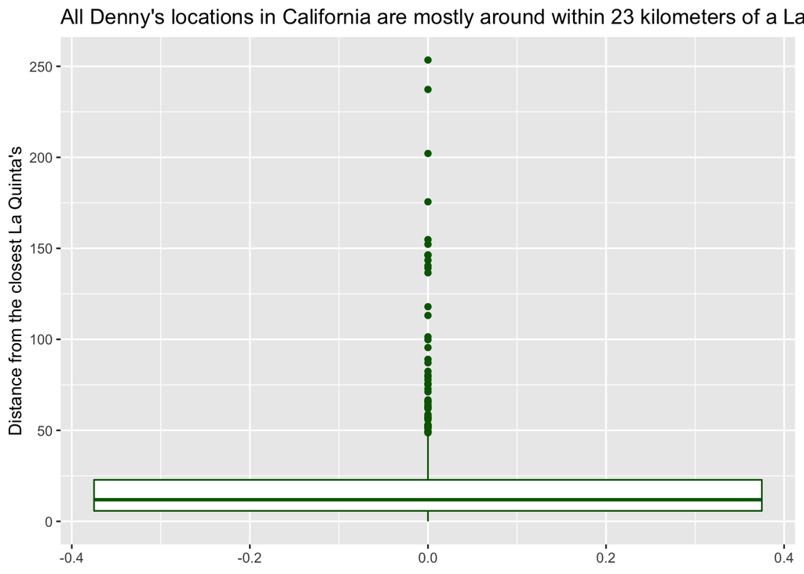

```r
# visualize the distribution of the closest distances
dn_lq_ca_mindist %>%
  ggplot(aes(y = closest)) +
  geom_boxplot(color = "dark green") +
  labs(
    title = "All Denny's locations in California are mostly around within 23 kilometers of a La Quinta's location",
    y = "Distance from the closest La Quinta's"
  )
```